# EDA

TJ Sipin

2022-06-22

## What is EDA?

Exploratory Data Analysis (John W. Tukey) ←→ Confirmatory Data Analysis

CDA requires assumptions. In practice, it is hard to check assumptions.

- Goal of EDA: simpler, but deeper description.
- Tools of EDA: simple arithmetic, easy-to-draw picture

EDA is numerical, counting, and graphical detective work. EDA is an essential step in data analysis to draw our intuition before modelling. EDA can provide crucial clues to establish proper assumptions.

Main components of EDA (4R) (in no particular order)

- Revelation: visual display
- Re-expression: simplify the behavior of data and clarify the analysis
- Resistance: keep outliers from affecting results
- Residual: attention on what remains in the data after analysis

Supporting your argument, EDA constitutes many pages.

> “I use this model based on what I found in the data through EDA.”

## Exploring the data

Before we start learning…  
Do NOT blindly apply what you think is fancy.

Take advantage of domain knowledge to understand what data is telling you. It is always worth searching how the data is collected.

Example:

$$Y: \text{ blood pressure} \qquad X:
\text{ amount of salt consumption}$$
How these components are collected may change which model is best for the given assumptions.

Albeit boring, EDA is still a key player to make different quality of data analysis.

“EDA is not about the fnacy, complicated graph. It’s about the simple graphs, showing intuition.”

## Stem-and-leaf display

Basic tools to see the distribution

- Histogram
- Stem-and-leaf display: organize data in histogram style but with digit number (stem function in R)

What do we want to detect?

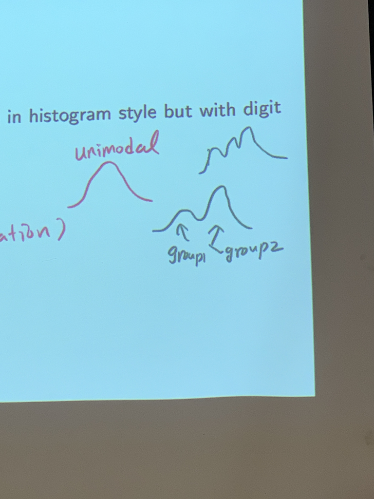

1. Centering -> location
2. Clusters (multi-model situation)
3. Asymmetry
4. Width (range) -> spread (variance)
5. Separation (gap)
6. Irregularities (outliers)

```r
stem(x, scale = 1)
```

scale: the indicator for the vertical length (default: 1) == size of “bins” in histogram.

scale > 1: long version - more detailed display

scale < 1: short version - rough display